# Разметка ЭКГ эксперимента 2

**Задача:** построить воспроизводимые кандидаты R-зубцов для 19 независимых записей размерного ряда и подготовить их к визуальной проверке. Автоматически найденные события не считаются принятой ЭКГ-разметкой.

Ноутбук использует только записи с принятой дыхательной разметкой `11.01`. Дыхательные интервалы не влияют на поиск R-зубцов, но позволяют определить, какие полные сердечные циклы находятся внутри одного режима и удалены от его границ. Все новые ЭКГ-результаты до отдельного решения сохраняются как кандидаты, ожидающие ручной проверки.

## Входные данные и область применимости

Список 19 независимых CSV задаётся принятыми дыхательными sidecar-файлами из `11.01`. Запись Ника 100 мм не входит в этот набор, поскольку она подтверждена как побайтовая копия записи 90 мм. Ноутбук проверяет идентификатор и полную контрольную сумму каждого CSV, а также отклоняет запись без принятой дыхательной разметки.

Кандидаты R-зубцов определяются только по времени `TIME_s` и сигналу ЭКГ `ECG_V`. Сначала ЭКГ фильтруется в полосе 5–15 Гц, затем автоматически выбирается преобладающая полярность и ищутся пики с заданными минимальными высотой, выраженностью и интервалом между соседними событиями. Найденная по фильтрованному сигналу вершина уточняется по исходной ЭКГ в окрестности ±50 мс.

Основной порог детектора берётся из локальной конфигурации. Дополнительный проход с вдвое меньшей высотой пика показывает чувствительность результата к порогу. События, появившиеся только при пониженном пороге, остаются диагностическими кандидатами и не добавляются автоматически.

Для каждого R-зубца строится модельное окно электрической систолы:

$$ QT = QT_c\sqrt{RR}, $$

где $QT$ — расчётная длительность окна, $QT_c$ — заданное скорректированное значение, а $RR$ — длительность соответствующего сердечного цикла. Это окно нужно только для последующего ансамблирования. Оно не является измеренным QT-интервалом и не подтверждает физиологическую интерпретацию формы сигнала.

Полным сердечным циклом здесь называется интервал от текущего R-зубца до следующего. Цикл связывается с дыхательным режимом, только если обе его границы находятся внутри одного принятого интервала после исключения защитного отступа 0,5 с с каждой стороны. Этот критерий служит предварительным отбором по времени; качество `RHEO2` и окончательная пригодность цикла оцениваются на следующем этапе.

```
Сохранён принятый ЭКГ-sidecar: 0afa461c34a0558e
Сохранён принятый ЭКГ-sidecar: 16e1fb61f5c4f94d
Сохранён принятый ЭКГ-sidecar: 38014daebf7ff78a
Сохранён принятый ЭКГ-sidecar: 3813722c0a78cfd5
Сохранён принятый ЭКГ-sidecar: 3eb16c060e856d45
Сохранён принятый ЭКГ-sidecar: 457a9c313389d102
Сохранён принятый ЭКГ-sidecar: 532548295b851498
Сохранён принятый ЭКГ-sidecar: 5c3d49578fcc44a2
Сохранён принятый ЭКГ-sidecar: 61792d81e4b89349
Сохранён принятый ЭКГ-sidecar: 74a1a7f4a6c3da1a
Сохранён принятый ЭКГ-sidecar: a4131daac20b73b0
Сохранён принятый ЭКГ-sidecar: abb001faf8162073
Сохранён принятый ЭКГ-sidecar: af9442f5b70f4964
Сохранён принятый ЭКГ-sidecar: c65e99bd76dba9a3
Сохранён принятый ЭКГ-sidecar: dc6569ff63a799cf
Сохранён принятый ЭКГ-sidecar: de3d881503ce81e8
Сохранён принятый ЭКГ-sidecar: ebac1f4aa63db94d
```

```
Сохранён принятый ЭКГ-sidecar: f230453caab02f7c
Сохранён принятый ЭКГ-sidecar: f8e058ae0d2a7d5b
ЭКГ-sidecar-файлов: 19
```

## Визуальная проверка и принятая ЭКГ-разметка

Для каждого добровольца проверены исходные ЭКГ, основные кандидаты R-зубцов, дополнительные события пониженного порога, последовательности RR-интервалов и увеличенные фрагменты с крупным смещением базовой линии.

Во всех 19 записях основные метки совпадают с повторяющимися положительными комплексами QRS. Последовательности RR не содержат разрывов, характерных для явного пропуска целого сердечного цикла, а уточнение вершины относительно фильтрованного сигнала не превышает 15 мс. Автор проекта утвердил основные списки R-зубцов без изменения. Уверенность в разметке принимается умеренной, поскольку независимая эталонная разметка отсутствует.

При пониженном пороге появились три дополнительных события: одно в записи Георга 130 мм и два в записи 140 мм. На увеличенных фрагментах они совпадают с изменением базовой линии и не включены в принятые списки. Это решение относится к текущим данным и параметрам детектора и не устанавливает универсальный оптимальный порог.

В ряде записей видны крупные низкочастотные смещения базовой линии. Их причина по этим данным не устанавливается; возможны движение, дыхательный манёвр, изменение контакта и другие факторы. R-зубцы на проверенных фрагментах остаются различимыми, поэтому временные метки ЭКГ сохранены. Соответствующие циклы нельзя считать пригодными для `RHEO2` только на основании принятой ЭКГ-разметки: они переданы в `12.01` как кандидаты на исключение или отдельную проверку.

Принятые решения привязаны к идентификаторам записей, версии алгоритма и контрольной сумме списка R-зубцов. Изменённая запись или новый результат детектора не наследует это решение автоматически.

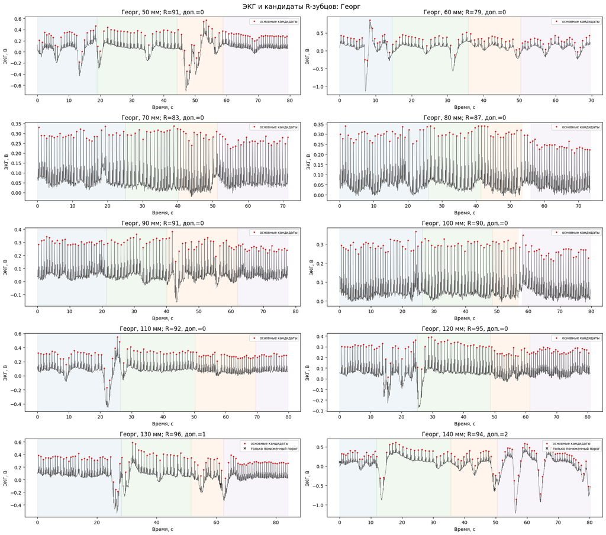

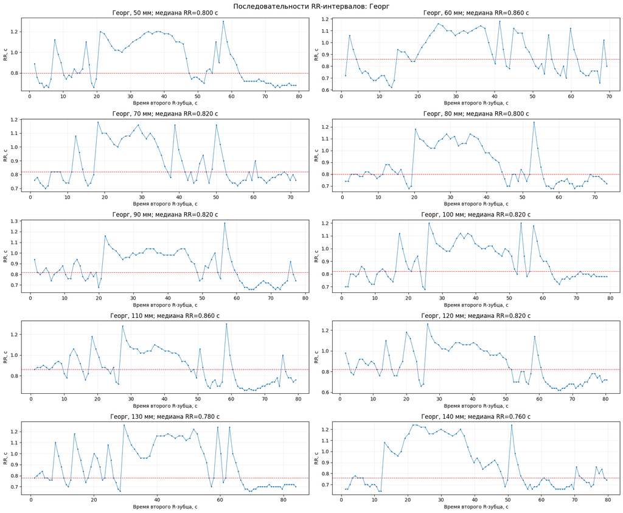

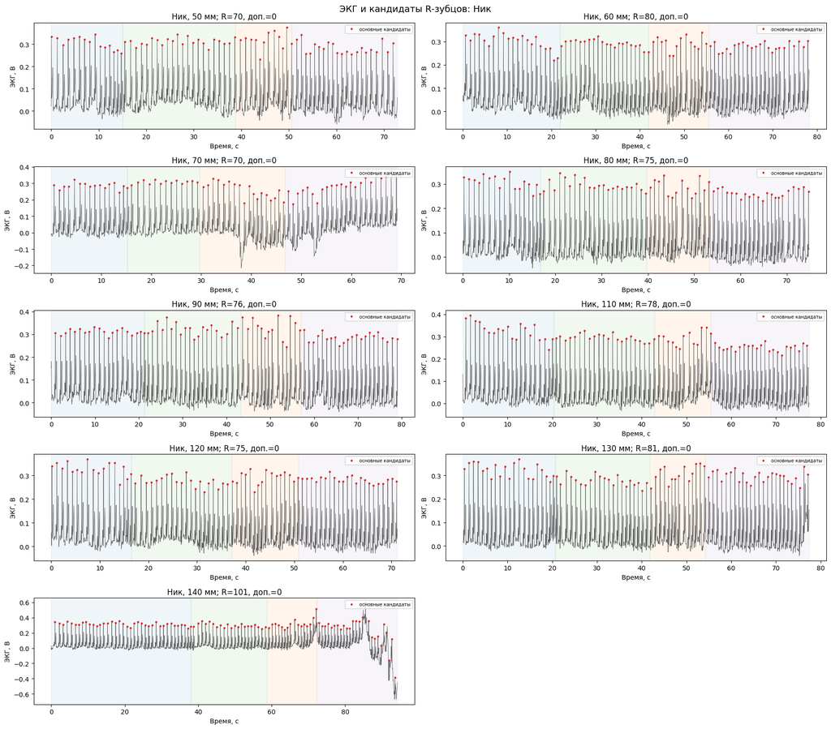

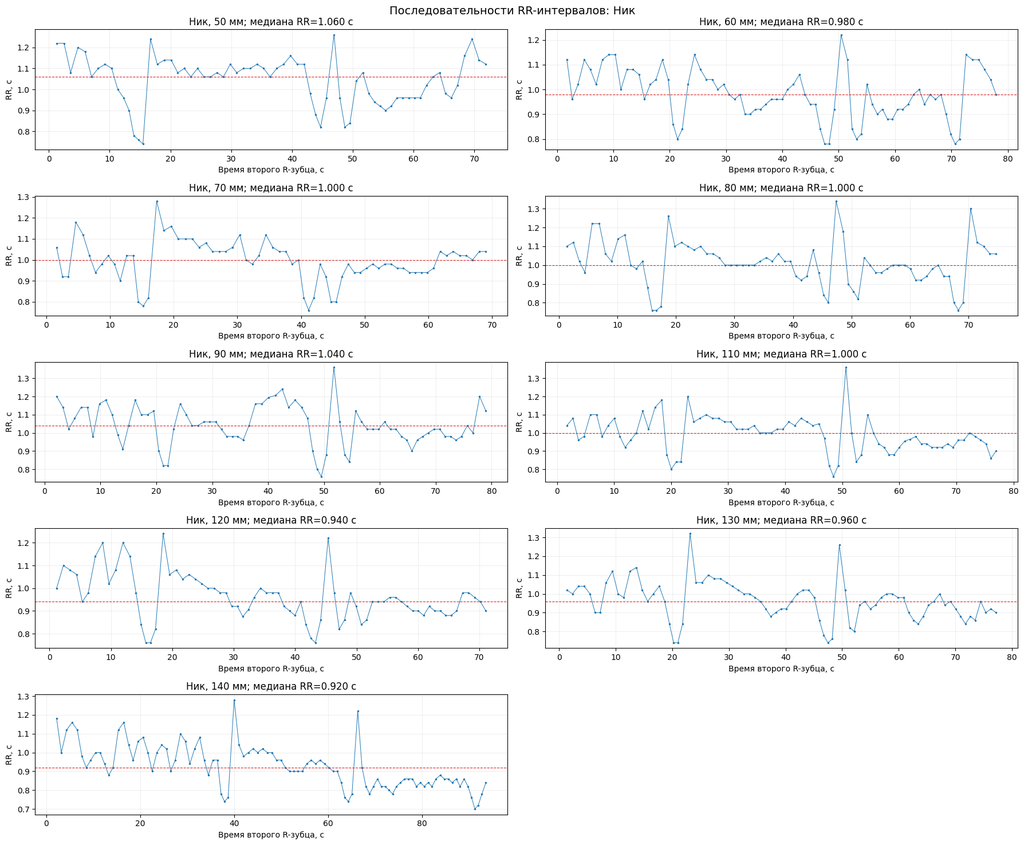

|  | доброволец | размер, мм | record_id | статус | решение | уверенность | кандидатные артефакты | полярность | R-зубцов | доп. кандидатов | частота, мин⁻¹ | медиана RR, с | мин. RR, с | макс. RR, с | CV RR | сдвиг вершины, мс | циклы: задержка вдох | циклы: задержка выдох | циклы вне режимов |
| --- | --- | --- | --- | --- | --- | --- | --- | --- | --- | --- | --- | --- | --- | --- | --- | --- | --- | --- | --- |
| 0 | Георг | 50 | af9442f5b70f4964 | принята | принят основной список | умеренная | 12–16 с; 45–58 с | 1 | 91 | 0 | 68.748 | 0.80 | 0.66 | 1.30 | 0.217 | 10.0 | 21 | 26 | 7 |
| 1 | Георг | 60 | 16e1fb61f5c4f94d | принята | принят основной список | умеренная | 7–9 с; 30–33 с; 49–51 с | 1 | 79 | 0 | 68.084 | 0.86 | 0.62 | 1.18 | 0.181 | 15.0 | 18 | 21 | 9 |
| 2 | Георг | 70 | 74a1a7f4a6c3da1a | принята | принят основной список | умеренная | не выделены | 1 | 83 | 0 | 69.728 | 0.82 | 0.70 | 1.18 | 0.160 | 10.0 | 13 | 24 | 7 |
| 3 | Георг | 80 | de3d881503ce81e8 | принята | принят основной список | умеренная | не выделены | 1 | 87 | 0 | 71.098 | 0.80 | 0.68 | 1.24 | 0.175 | 10.0 | 13 | 21 | 12 |
| 4 | Георг | 90 | dc6569ff63a799cf | принята | принят основной список | умеренная | 41–44 с | 1 | 91 | 0 | 70.343 | 0.82 | 0.66 | 1.28 | 0.159 | 10.0 | 16 | 19 | 9 |
| 5 | Георг | 100 | ebac1f4aa63db94d | принята | принят основной список | умеренная | 56–59 с | 1 | 90 | 0 | 67.822 | 0.82 | 0.68 | 1.20 | 0.151 | 10.0 | 20 | 25 | 7 |
| 6 | Георг | 110 | 38014daebf7ff78a | принята | принят основной список | умеренная | 20–25 с | 1 | 92 | 0 | 69.156 | 0.86 | 0.66 | 1.30 | 0.177 | 10.0 | 22 | 12 | 7 |
| 7 | Георг | 120 | c65e99bd76dba9a3 | принята | принят основной список | умеренная | 13–28 с | 1 | 95 | 0 | 70.527 | 0.82 | 0.62 | 1.26 | 0.191 | 10.0 | 20 | 26 | 8 |
| 8 | Георг | 130 | a4131daac20b73b0 | принята | принят основной список | умеренная | 25–32 с; 54–63 с | 1 | 96 | 1 | 68.555 | 0.78 | 0.66 | 1.26 | 0.209 | 10.0 | 19 | 28 | 7 |
| 9 | Георг | 140 | 532548295b851498 | принята | принят основной список | умеренная | 10–16 с; 44–58 с; 62–66 с; 76–81 с | 1 | 94 | 2 | 70.307 | 0.76 | 0.64 | 1.24 | 0.224 | 15.0 | 19 | 39 | 5 |
| 10 | Ник | 50 | f230453caab02f7c | принята | принят основной список | умеренная | 11–17 с; 44–50 с | 1 | 70 | 0 | 57.676 | 1.06 | 0.74 | 1.26 | 0.113 | 10.0 | 19 | 20 | 8 |
| 11 | Ник | 60 | 457a9c313389d102 | принята | принят основной список | умеренная | не выделены | 1 | 80 | 0 | 61.365 | 0.98 | 0.78 | 1.22 | 0.104 | 10.0 | 18 | 21 | 8 |
| 12 | Ник | 70 | 3eb16c060e856d45 | принята | принят основной список | умеренная | 36–50 с | 1 | 70 | 0 | 60.676 | 1.00 | 0.76 | 1.28 | 0.099 | 10.0 | 11 | 21 | 7 |
| 13 | Ник | 80 | 5c3d49578fcc44a2 | принята | принят основной список | умеренная | не выделены | 1 | 75 | 0 | 60.144 | 1.00 | 0.76 | 1.34 | 0.120 | 10.0 | 20 | 20 | 8 |
| 14 | Ник | 90 | 61792d81e4b89349 | принята | принят основной список | умеренная | не выделены | 1 | 76 | 0 | 57.707 | 1.04 | 0.76 | 1.36 | 0.107 | 10.0 | 19 | 20 | 7 |
| 15 | Ник | 110 | f8e058ae0d2a7d5b | принята | принят основной список | умеренная | 51–56 с | 1 | 78 | 0 | 60.449 | 1.00 | 0.76 | 1.36 | 0.100 | 10.0 | 19 | 21 | 8 |
| 16 | Ник | 120 | 3813722c0a78cfd5 | принята | принят основной список | умеренная | не выделены | 1 | 75 | 0 | 63.184 | 0.94 | 0.76 | 1.24 | 0.108 | 10.0 | 19 | 20 | 8 |
| 17 | Ник | 130 | 0afa461c34a0558e | принята | принят основной список | умеренная | не выделены | 1 | 81 | 0 | 62.774 | 0.96 | 0.74 | 1.32 | 0.109 | 10.0 | 19 | 23 | 9 |
| 18 | Ник | 140 | abb001faf8162073 | принята | принят основной список | умеренная | 84–95 с | 1 | 101 | 0 | 64.318 | 0.92 | 0.70 | 1.28 | 0.125 | 10.0 | 19 | 25 | 7 |

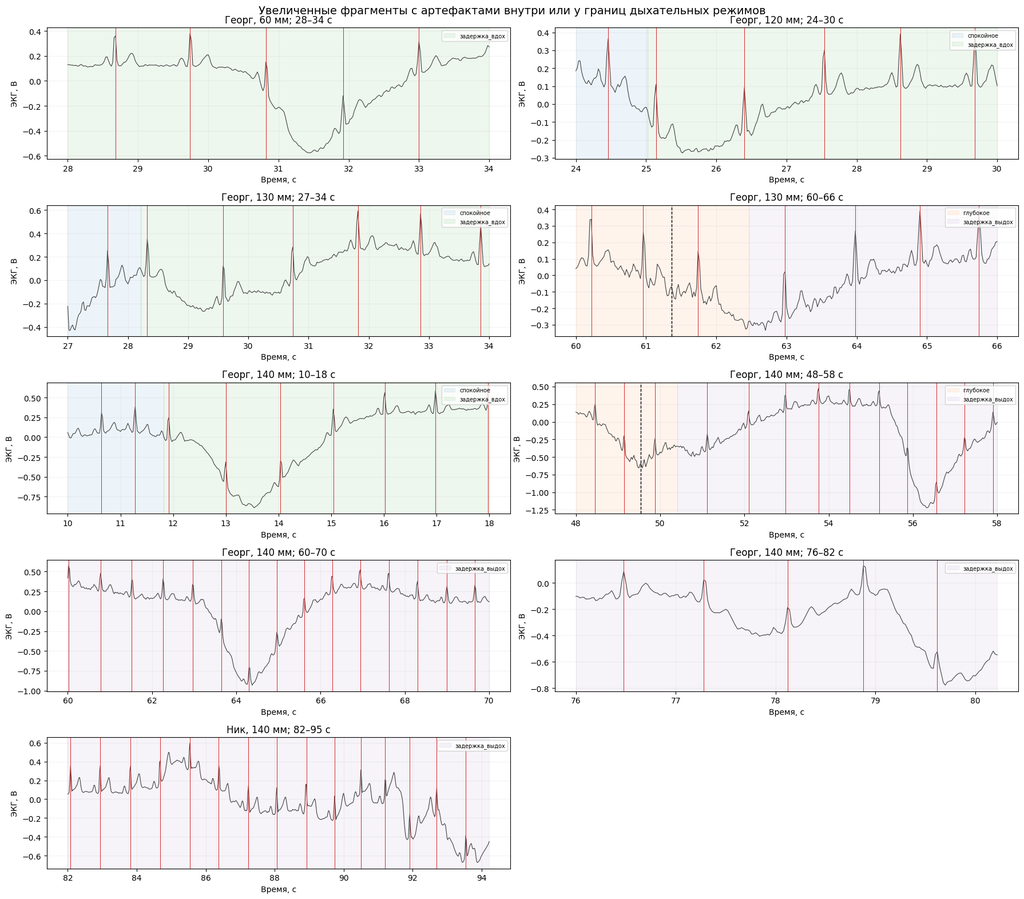

## Результат и следующий этап

Для 19 независимых записей приняты основные списки R-зубцов. Три события, появившиеся только при пониженном пороге, не добавлены. Для каждой записи сохранены полярность, основание решения, умеренная уверенность и история проверки.

Отдельно записаны кандидатные интервалы крупного смещения базовой линии. Они не отменяют временную привязку видимых R-зубцов, но ограничивают пригодность соответствующих циклов для количественного анализа `RHEO2`.

Сопроводительные ЭКГ-файлы находятся вне Git в `derived/exp02/annotations/ecg/`. Каждый файл связан с исходным CSV через полную контрольную сумму и с принятой дыхательной разметкой через контрольную сумму её sidecar-файла.

`12.01` должен совместно проверить дыхательные интервалы, полные сердечные циклы и качество `RHEO2`. Только после этой проверки циклы можно передавать в расчёт пульсового отклика боковых сборок.